# Final Report

Jaxon Abercrombie

8/7/2022

# PM-606 Final Report

## About the Project

### Project Background

For the summer 2022 semester PM-606 Health Data Science Practicum, we were tasked with utilizing a dataset from the California Teacher Study (CTS) with a focus on OSHPD hospitalization records. The dataset, particularly containing hospitalization information from participants between the years 2000 to 2015, had over 150 features related to participants’ baseline characteristics from questionnaires (age, race, family history, etc.) and their hospitalization information (procedures, length of stay, etc.). Using skills developed through core courses of the PHDS master’s degree curriculum, we were expected to handle a large number of study participant records to make conclusions for four main aims.

### Project Aims

The four main aims of the project were:

1. Develop a best fitting model (either regression or machine learning) to predict the probability of death within a certain time window based on a plethora of participant features (patient-specific and hospitalization-specific)
2. Assess whether the time window after hospitalization plays a role in predicting death
3. Assess whether co-morbidities play a role in predicting the risk of death
4. Determine whether there are temporal or spatial trends in hospitalization-related deaths

## Abstract

**Background:** Using the CTS dataset, many prediction models of varying types were created for participants who passed away within thirty days after hospital discharge, as well as those who passed between the thirty-first day and sixth month mark. Focus was placed on “discharge to death” categories that were considered more recent to hospitalization, as too much elapsed time may introduce unreported changes in participant health history, behaviors, and other features (ex: passing away after three years may not be attributable to hospitalization compared to passing away within a week). Especially as recovery may produce many risks for death, tackling the first thirty day category is of the most interest and will likely bring more efficient models. Of the six discharge to death window categories created, the two that were used were the 0-30d and 31d-6mo categories.

**Methods:**

Data handling: First, data was extensively cleaned and wrangled for model-building, which included meticulously reviewing the provided data dictionary, removing duplicate instances, identifying clinically relevant features to prioritize, ensure consistency in variable types, handling missing values, creation of new variables, and conducting preliminary univariate and multivariate analysis through table creation and visualization. Such analyses helped to make a conclusion about the fourth aim concerning spatial and temporal trends in deaths. A subset of roughly 60 features was the final result after the processes previously described. Handling data took majority of the project time-wise, as evaluating an abundance of features on a one-by-one basis is a tedious task. Additionally, certain “branding” aesthetics, like using the same colors for visualization, were followed to make the report cohesive visually.

Model creation: After proper handling of data and implementing a data split of 70:30, models could be created with ease. Because the aim of the project was to create a binary classifier, there was a clearly-defined list of models to choose from. To implement a variety of methods, three main model types were pursued for the two target groups (first 30 days and 31d-6m): random forest models, logistic regression models, and extreme gradient boosting models. Feature selection for each model varied on some model restrictions revolving around the number of factors able to be handled, preference for parsimony, and highly correlated features. Because of the highly imbalanced classes (surviving participants heavily outweighing deceased), models were built with that in mind and the statistic used to compare models was balanced accuracy. Balanced accuracy was calculated by averaging the specificity and sensitivity from the model being run on the test set of data. AUC was ruled out as a staisticto compare performance because of the imbalance in the target variable classes.

**Conclusions:** After comparing balanced accuracy among the total of 6 models, it became evident that certain model types suited different participant categories more efficiently than others. With a balanced accuracy of 95.10%, the extreme gradient boosting model was most efficient for predicting participants’ death in the first thirty days post-discharge. On the other hand, with a lower balanced accuracy of 53.71%, the random forest model was most efficient for predicting participants’ death between the first thirty-one days and sixth month mark post-discharge. Regardless, many variables were identified as “important” across all model types, with patient disposition, cancers, major diagnosis codes, and health behaviors like diet and smoking most prominent in assisting model performance. Based on the difference in model performance for the different windows after discharge, it was evident that elapsed time post-discharge affects one’s ability in predicting death. Furthermore, havgin certain co-morbidities, like specific cancer types, as well as the number of co-morbidities someone had, affected one’s risk of death. Higher number of co-morbidities was associated with higher risk of death. Lastly, looking at the fourth aim of the project, lack of variance in seasonality across deaths demonstrated that temporal association for death was non-existent. Spatial differences were more difficult to discover without proper supplemental data, but inferences about death disproportionately affecting more rural areas lacking resources could be made.

## Data Pre-Processing, Cleaning, and Wrangling

### Importing Data

A CSV file was created from the provided data call R file for the project (“10017_USCDAT_v01_20210609_2220_R_data_call_Jaxon_Abercrombie”). The file contains the combined dataset, and it solely contains data for eligible participants. All duplicate rows were removed to keep the dataset cleaner and duplicates could have potentially skewed data when creating summary statistics.

```r
# Read in the created CSV file
data <- read.csv("distinct_combined_data.csv")
```

### Looking at Basic Data Frame Characteristics

Basic characteristics of the dataset would be observed—like its dimensions,first and last instances, and missing value counts per feature—to become acquainted with the dataset in R.

| X | participant_key | date_of_birth_dt | date_of_death_dt | cause_of_death_cde | cause_of_death_dsc | qnr_1_fill_dt | qnr_2_fill_dt | qnr_3_fill_dt | qnr_4_fill_dt | qnr_4_mini_fill_dt | qnr_5_fill_dt | qnr_5_mini_fill_dt | qnr_6_fill_dt | breast_cancer_res_only_ind | ses_quartile_ind | blockgroup90_urban_cat | hysterectomy_dt | hysterectomy_ind | bilateral_mastectomy_dt | bilateral_mastectomy_ind | bilateral_oophorectomy_dt | bilateral_oophorectomy_ind | first_moveout_ca_dt | age_at_baseline | adopted | twin | birthplace | birthplace_mom | birthplace_dad | … |
| --- | --- | --- | --- | --- | --- | --- | --- | --- | --- | --- | --- | --- | --- | --- | --- | --- | --- | --- | --- | --- | --- | --- | --- | --- | --- | --- | --- | --- | --- | --- |
| 0 | 0 | 0 | 32034 | 25400 | 32208 | 0 | 5002 | 0 | 14620 | 45265 | 20705 | 47158 | 33141 | 0 | 713 | 693 | 30265 | 0 | 47696 | 0 | 36507 | 0 | 43899 | 0 | 6178 | 6583 | 617 | 843 | 714 | … |

The data set contains 48324 observations and 165 variables. These components denote that there are 48324 eligible participants for analysis and up to 165 available variables for each participant. The variables of this dataset primarily relate to birth and death dates, hospital admission and discharge dates, demographic characteristics (age, ethnicity, race), medical history (past diagnoses), health behaviors (sleep, diet, smoking), and metrics like height and weight—among many others.

Additionally, the number of missing values were counted across all variables in the dataset. Fortunately, the majority of missing values are attributable to a missing date for a procedure a participant never had, if questionnaires were not filled out by a participant entirely, if a participant never partook in a certain health behavior, or if a patient did not have a death date due to their current state of being alive. Furthermore, some missing values were also because only “Yes” was recorded in the dataset, meaning all other values were “No,” for example. These values, present with self-reported diagnosis variables, would be investigated further and handled in the next part of this report.

### Ensuring Variable Consistency

After deciding which variables would be looked at initially, it was important to understand how variables could be made consistent in their values and types as seen in the data dictionaries. While many variables followed either a 0 and 1 binary value format, some follow an ‘A’ and ‘B’ or “Y” and “N” value format as well. It is crucial to keep in mind that “A” is equivalent to “Y” and 1 moving forward. That way, when reporting outputs and understanding models, there is no mix up. Furthermore, some binary variables technically included third options to indicate a participant not knowing their status, often denoted as “Z.”

Additionally, to make sure variables were following their intended variable type (num, char, date, etc.), column types for each variable were compared to data dictionaries. All variables of the type “character” were changed to factor variables for the sake of later imputation and usage in models, and integer or numeric variables were later changed to factor variables on a case-by-case basis (often those following a binary pattern).

### Handling Missing Values and Outliers

For missing values, the only variables that could possibly undergo imputation were variables that have missing values on the basis of actually being missing. In other words, values for dates or choosing a random value for a participant’s diabetes status would be less acceptable. On the other hand, values that have more potential to be inferred, like sleep hours, based on the average or median sleep hour values would be more acceptable here. That would be done categorically, like imputing average sitting hours by gender. Before any handling, it was crucial to note that some values would be missing because such values were never available. For example, if a participant did not smoke or drink, there would naturally be missing values for smoking- and drinking-related variables for participants who never partook in such activities. For the sake of model-building and some models being unable to handle missing values, imputation was carried out by using mean values for integer and numeric variables and mode for factor variables.

To ensure there are no painfully obvious outliers, minimum and maximum values would be assessed for each variable used. The provided data dictionaries would be come helpful here once again, as ranges of values are listed in the dictionaries to ensure no values are too small or large upon comparison between the dataset in R and the dictionary. Code output is hidden to avoid extraneous length to report.

Even if missing values were kept in some regard, the percent of missing values are often below 5% for all investigated variables. This indicated that keeping missing values would not have impacted models too significantly (granted they couldhandle NA values). The only variables that may be of concern with the large number of missing values are those related to something like smoking, which near almost 35,000 missing values for each variable. However, such values are missing likely because of values not being applicable (ex: the participant is not a smoker and therefore does not engage with smoking). Many people evidently have not smoked, for example, which matches up well with the findings related to the large number of missing values for smoking-related variables. Imputation ended in there being 0 missing values in the dataset. Imputation was carried out by imputing mean values for integer and numeric variables, with mode values being imputed for categorical or factor variables.

All numerical values and their respective minimums and maximums were compared to provided value ranges in data dictionary. None were outside of expected boundaries. Additionally, no particular outliers were found in visualizations made in Tableau Reader, which was great to have to check in other way. With missing values handled and outliers checked, creating new variables came next.

### Creation of New Variables

Once all variables were looked over to gauge completeness and consistency, creating new variables was the next step involved. From variables like birth date, admission date, discharge date, death date, diagnoses, and medications, many others could be created. The list of variables and their description are below:

- Number of ICD Diagnoses:
  - Counts number of ICD diagnoses from the maximum five given
  - To see if number of diagnoses impacts risk of death significantly
- Number of Comorbidities:
  - Counts number of comorbidities from the maximum four diagnosis CCS codes
  - To see if number of comorbidities impacts risk of death significantly
- Number of Procedures Performed on Participant During Stay:
  - Counts number of procedures from the procedure variables in dataset
  - To see if number of procedures performed impacts risk of death significantly
- Time to death
  - Looks at how many days from discharge it takes for a given participant to pass away
- Time to death (categorical)
  - Looks at whether someone passed within the first month, between the second and sixth month, etc.
  - Will be helpful when sorting instances to use for models (ex: solely using 0-30 days, etc.)
- Seasonality of death, admission, and discharge
  - To see if there are any interesting seasonal patterns in when most people are admitted, discharged, or pass away
  - Uses months to figure out season; not using solstices for ease of boundaries
- Age at time of death
  - Uses birth and death date (where applicable) to get the age at which someone passed away
  - That way, if their age is extremely high, death may be attributable to age
  - Additionally, this gives more insight than age at baseline in relation to death
- Number of medications taken
  - Counts how many medications a person takes daily (self-reported)
  - Used to investigate whether taking multiple medications makes for higher risk of death

```
## [1] 0
```

### Identifying Main Variables of Interest

Especially because over 150 variables may be overwhelming to look through, a certain focus would be decided by reducing the number of variables of primary interest looked at in this progress report. Tableau Reader was used to look at variables and their respective relationships with one another. Of course, variables could be added or removed from this preliminary and exhaustive list depending on reassessment of variables. After using Tableau and browsing data dictionaries, the variables listed below were the main ones of interest and clinical importance:

- Variables related to birth, death and age
  - Date of birth
  - Birthplace
  - Date of death (as applicable)
  - Cause of death (as applicable)
  - Deceased
  - Age at baseline
- Variables related to demography and personal characteristics
  - SES quartile
  - Participant race
  - Ethnic category
  - Live near oil refinery
  - Height, weight, and BMI
- Variables related to medical history and behaviors
  - Procedures (hysterectomy, mastectomy, oophorectomy, mammogram)
  - Diagnoses (ICD codes, major diagnosis category code, cancers, diabetes, stroke, heart attack, high blood pressure, asthma)
  - Medications (total years used contraception, high blood pressure medicine, NSAID, insulin, ace inhibitor, tamoxifen, oral steroids, inhaler, antidepressant, cholesterol lowering medication)
  - Behaviors (physical activity, standing and sitting hours, diet, smoking, alcohol usage)
  - Others (menarche, pregnancy)
- Variables related to visits, facilities, and costs
  - Payer category code
  - Facility county code
  - Facility zip code
  - Patient care type
  - Source admission code
  - Participant length of stay
  - Admission type and date
  - Discharge date

```
## [1] 0
```

Data was then complete and ready for exploration.

## Data Exploration

### Univariate Analyses

Main variables were looked into univariately in Tableau Reader, and any particularly interesting or important visualizations and statistics were repeated below.

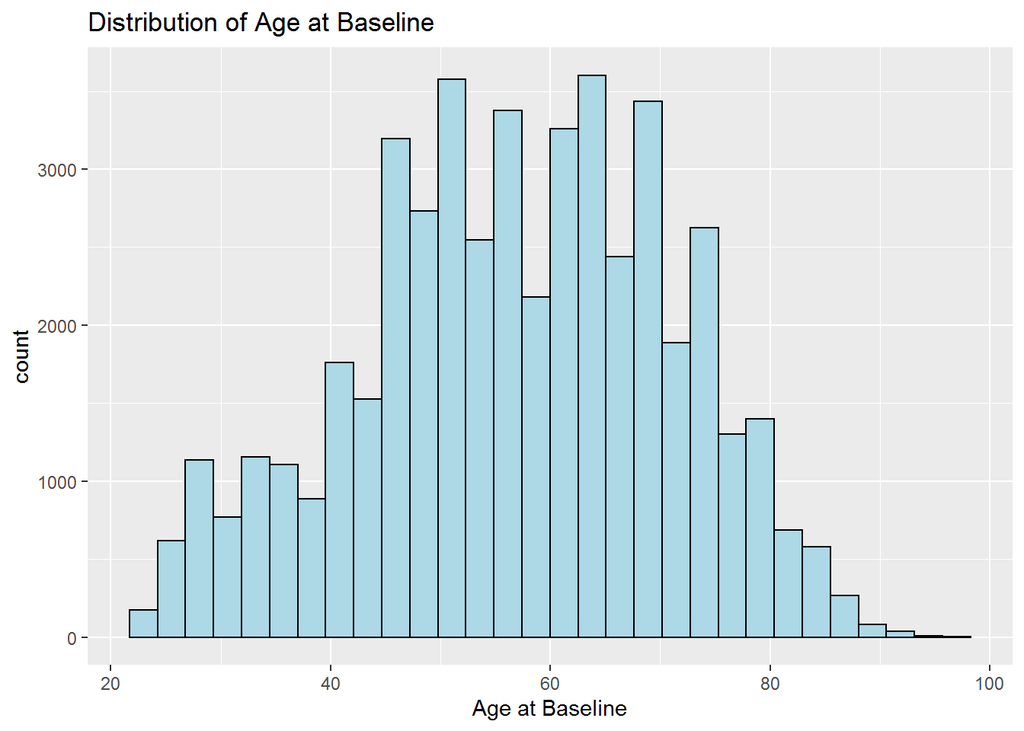

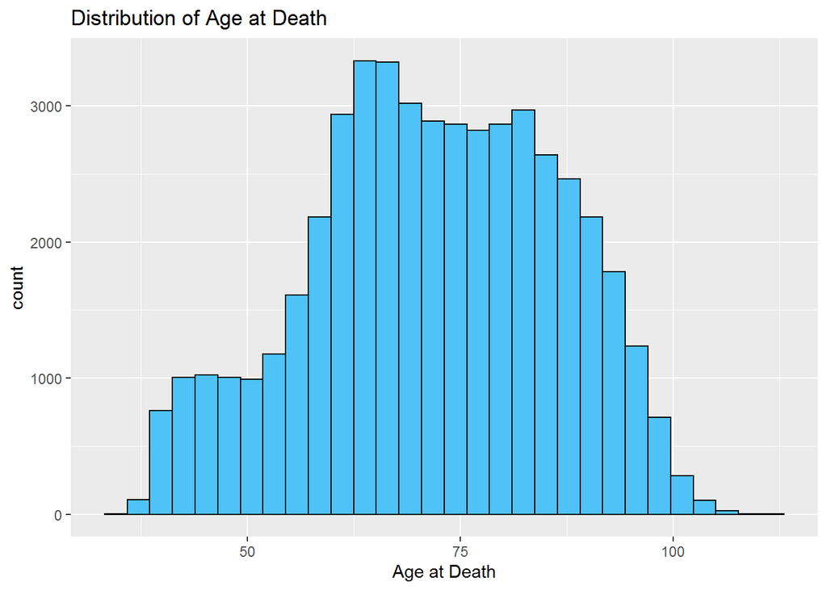

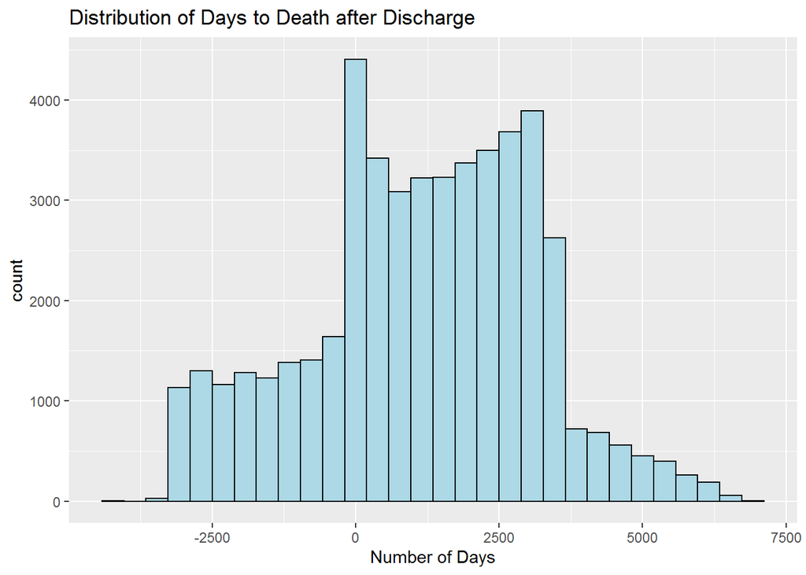

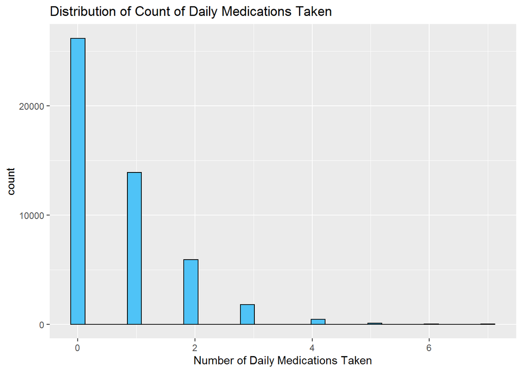

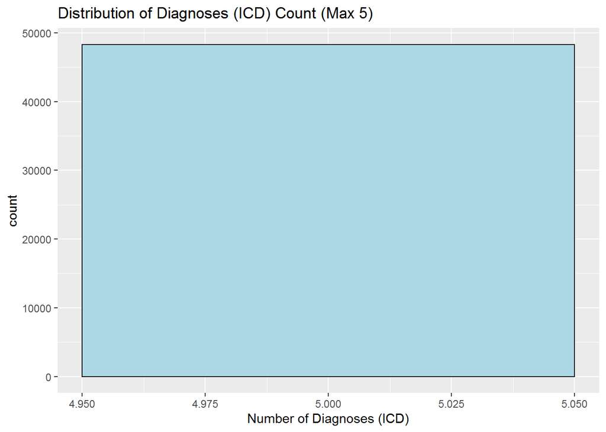

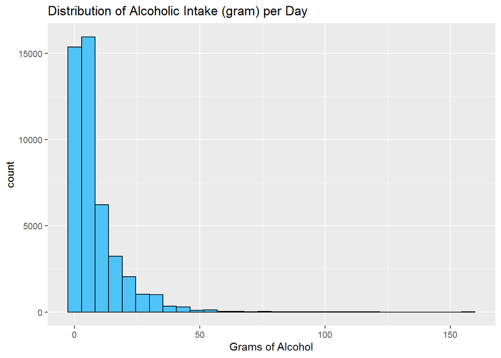

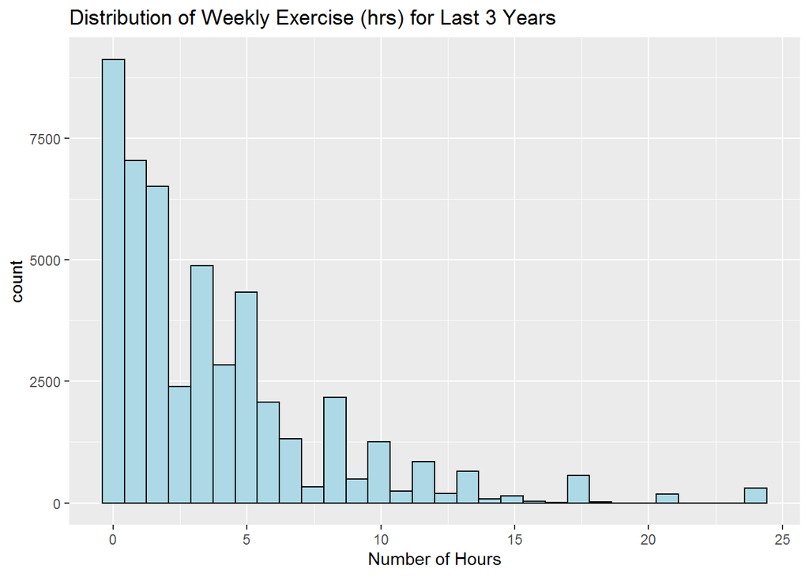

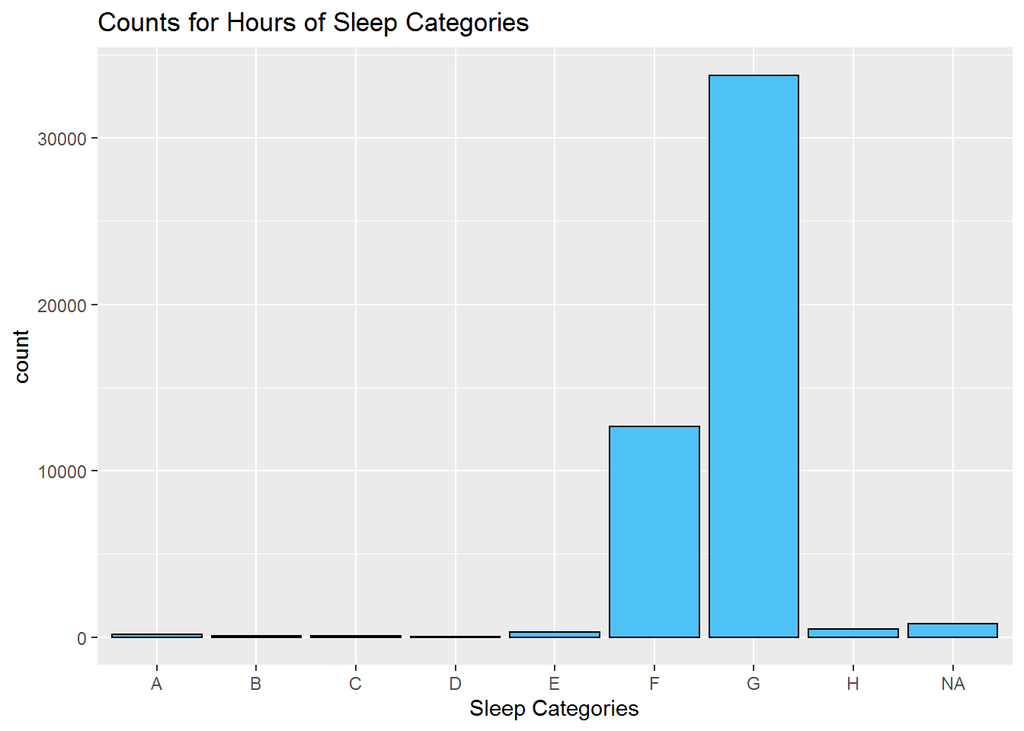

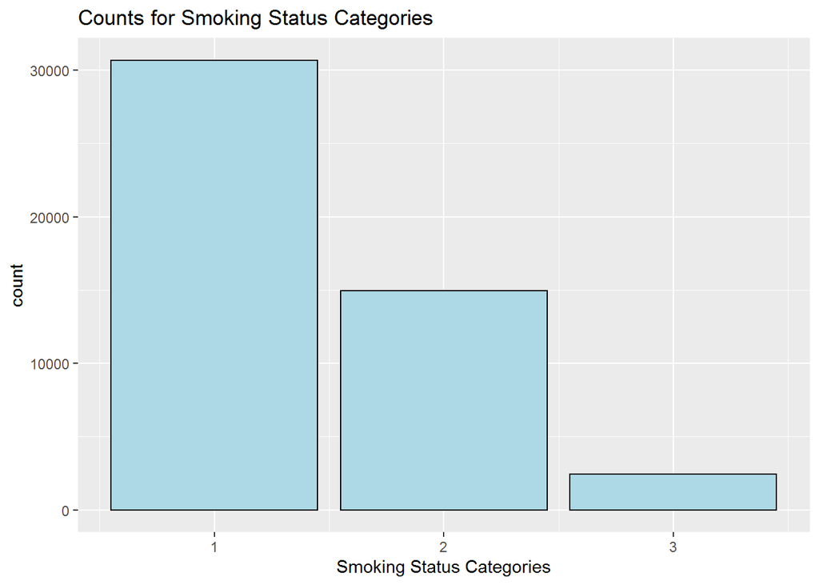

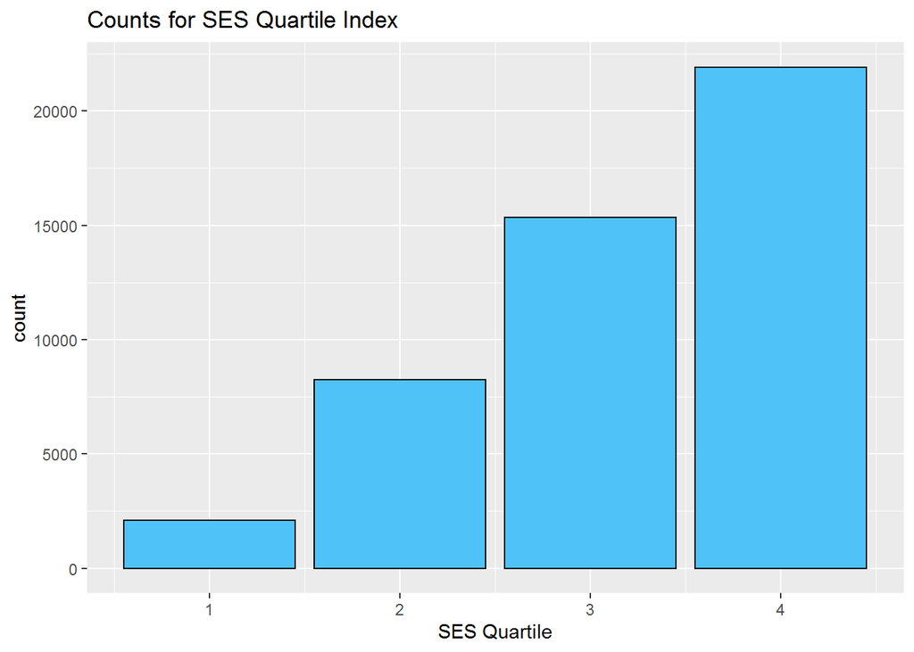

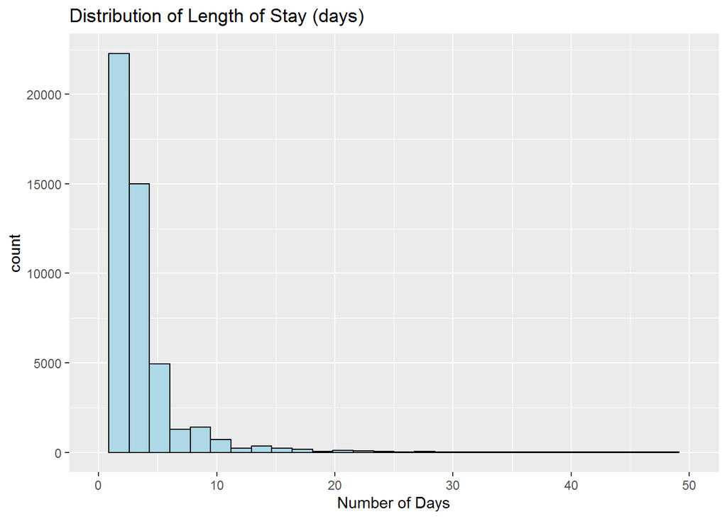

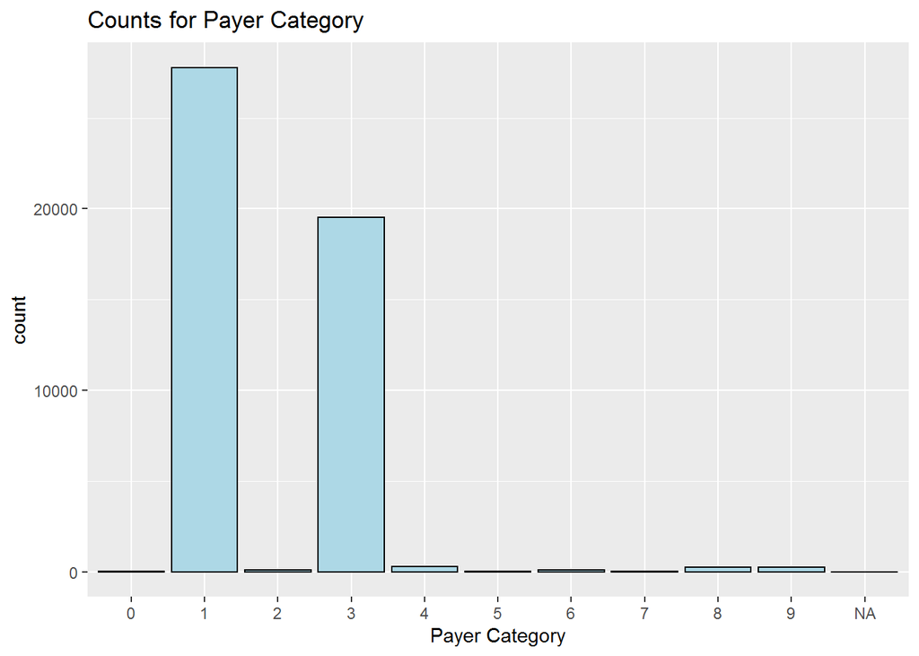

[3 more figures not shown]

### Bivariate Analyses

Main variables were looked into bivariately in Tableau Reader, and any particularly interesting or important visualizations, relationships, and statistics were repeated below.

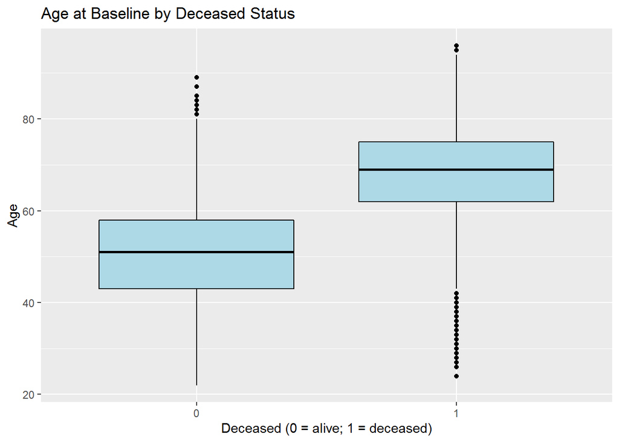

[figure not shown]

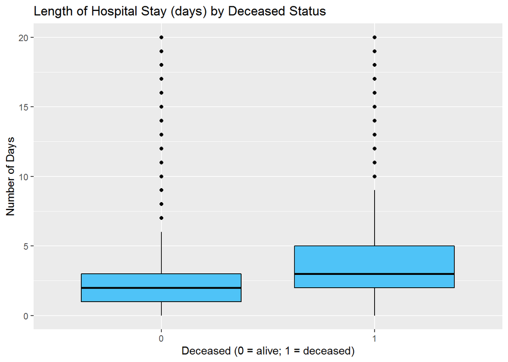

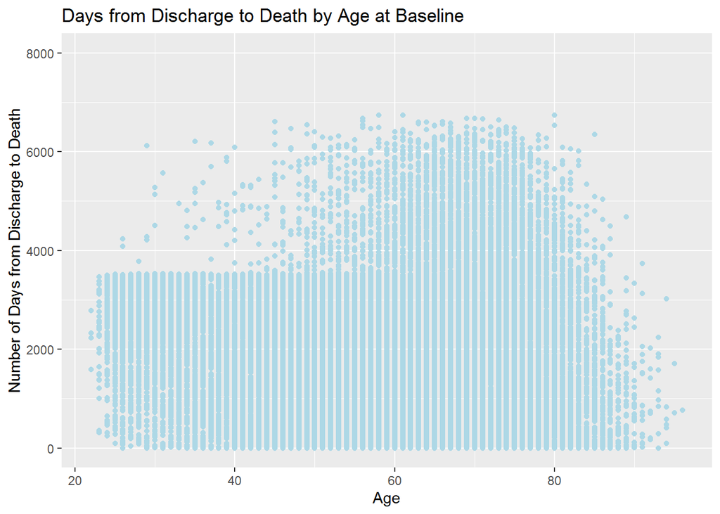

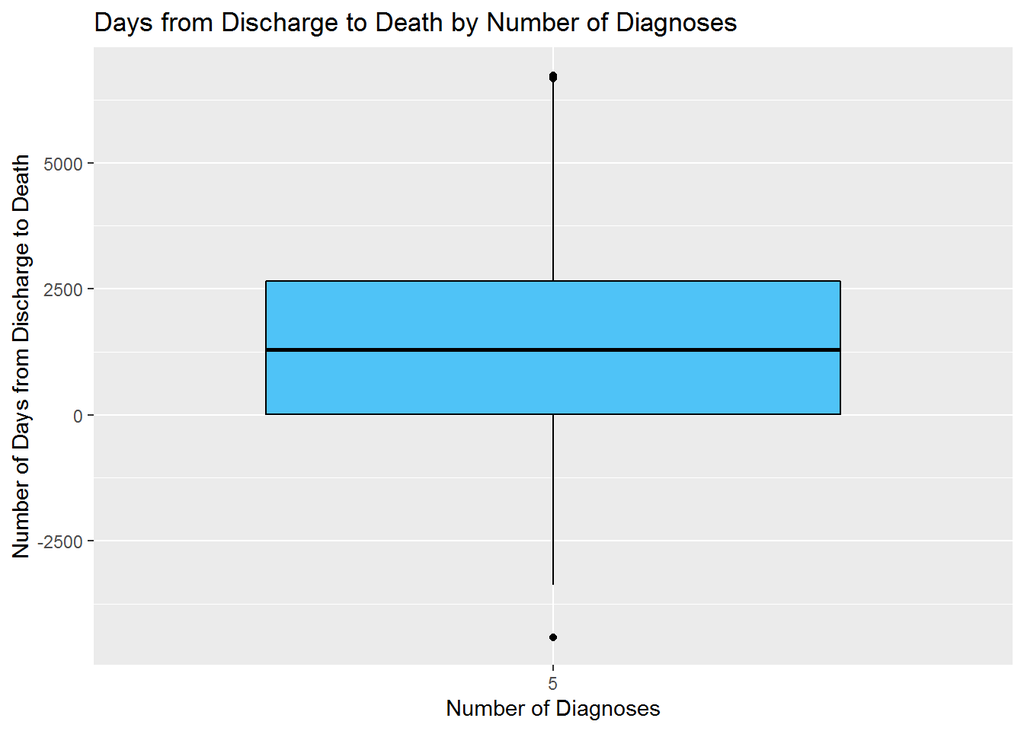

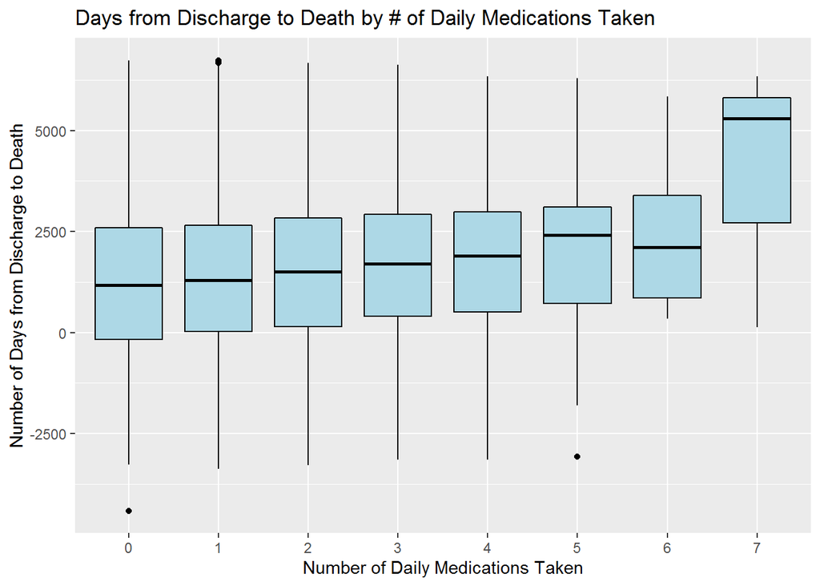

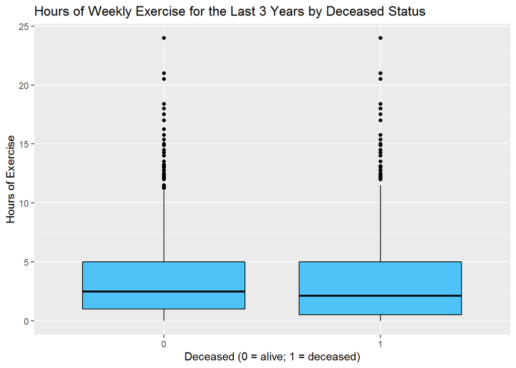

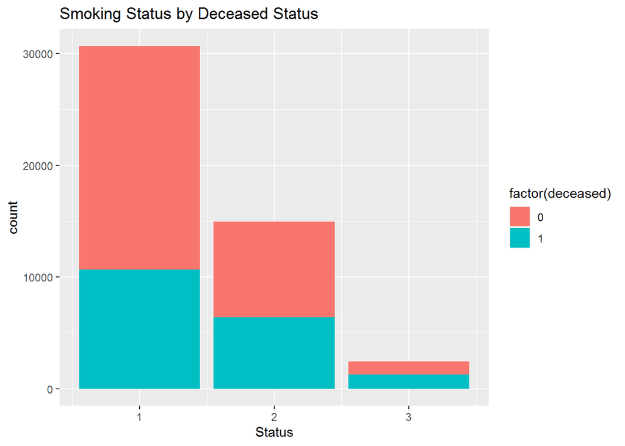

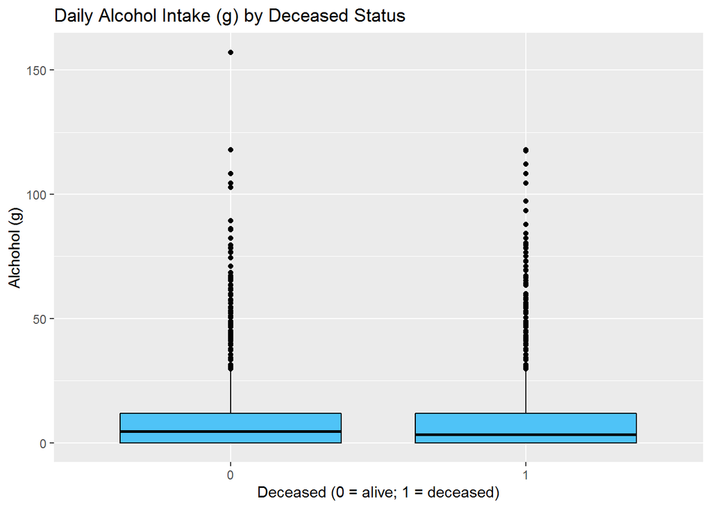

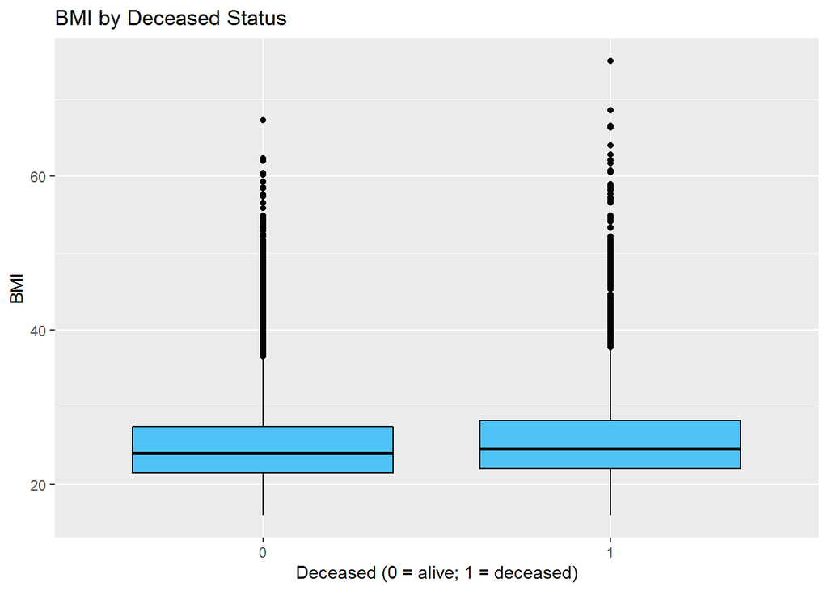

```
## # A tibble: 5 x 2
## # Groups:   facility_county_cde [5]
##   facility_county_cde     n
##                 <int> <int>
## 1                  19  2145
## 2                  37  1051
## 3                  30  1034
## 4                  43   597
## 5                  34   563
```

Based on these exploratory analyses, inclusion of certain variables in model-building seems crucial to predictive performance. Especially because many of these variables have a lot of variance or appear different depending on deceased status, that will particularly help in models.

## Model Building

### Carrying Out Data Splits

For model-building, the standard 70:30 training and testing split would be used. This would supply ample testing data for understanding model performance. The splitting of data resulted in data frames for both training and testing.

### Random Forest Model(s)

Random forest models were tackled first, as the variable importance plot function was used to get ideas for which features to include in later model types. The more important a variable would be in the following models, the more inclined I would be to use it in a subsequent model type. A model was made for the 0-30d window and 31d-6mo window. From the subset of roughly 60 variables, competing target variables (ex: removing 31d-6mo binary variable when making a 0-30d death prediction model) and factor variables with too many levels were removed in order to run the model efficiently. To correct the imbalance of classes for the target variable, sample sizes were manually edited to reflect the count of the minority class in the training set. The *mtry* parameter was made to be the square root of the number of features used in the model. AUC and ROC plot outputs were made for each model despite an imbalanced target variable. Balanced accuracy was calculated for each variable.

```
##
##     0     1
## 32810  1017
```

```
## Area under the curve: 0.8805
```

```
## 95% CI: 0.8606-0.9003 (DeLong)
```

```
## Confusion Matrix and Statistics
##
##           Reference
## Prediction     0     1
##          0 12701  1380
##          1   128   288
##
##                Accuracy : 0.896
##                  95% CI : (0.8909, 0.9009)
##     No Information Rate : 0.8849
##     P-Value [Acc > NIR] : 1.287e-05
##
##                   Kappa : 0.2416
##
##  Mcnemar's Test P-Value : < 2.2e-16
##
##             Sensitivity : 0.9900
##             Specificity : 0.1727
##          Pos Pred Value : 0.9020
##          Neg Pred Value : 0.6923
##              Prevalence : 0.8849
##          Detection Rate : 0.8761
##    Detection Prevalence : 0.9713
##       Balanced Accuracy : 0.5813
##
##        'Positive' Class : 0
##
```

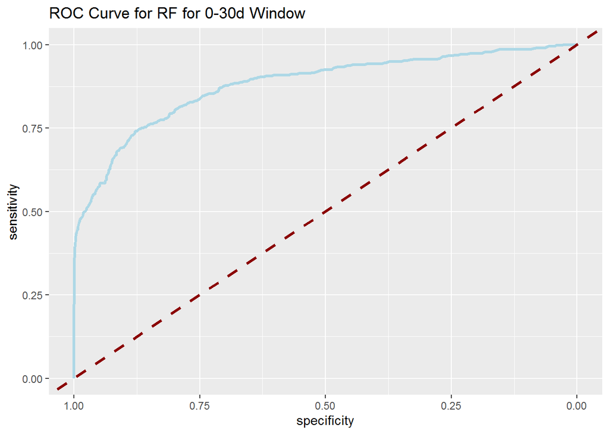

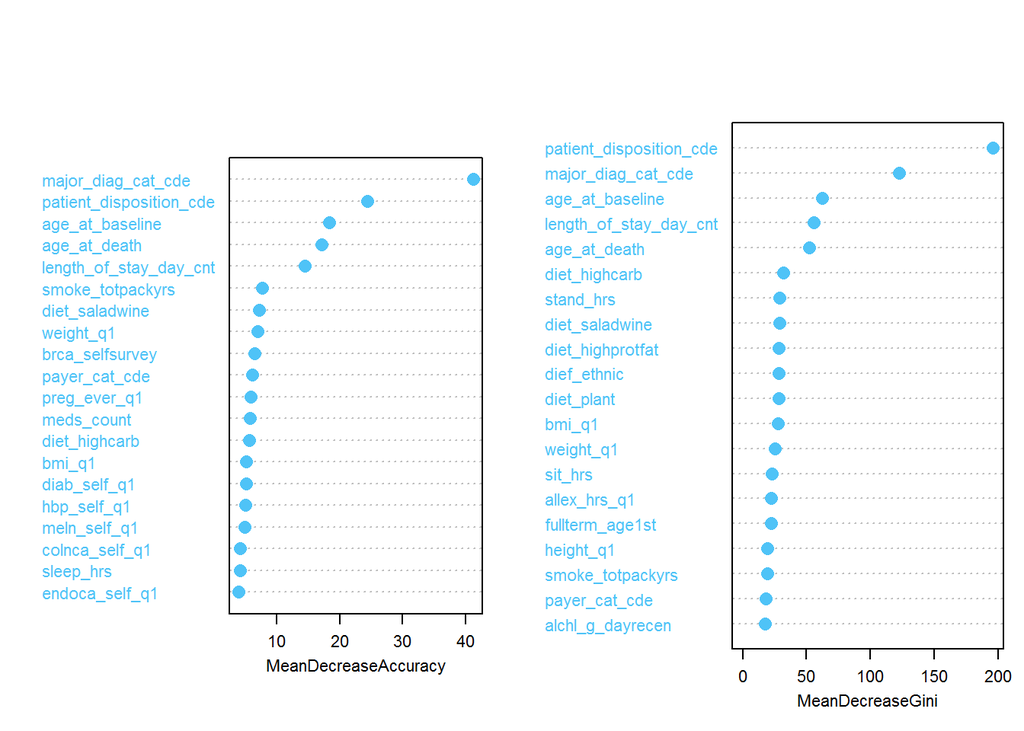

```
##
##     0     1
## 32435  1392
```

```
## Area under the curve: 0.7201
```

```
## 95% CI: 0.6997-0.7404 (DeLong)
```

```
## Confusion Matrix and Statistics
##
##           Reference
## Prediction     0     1
##          0 12388  1488
##          1   440   181
##
##                Accuracy : 0.867
##                  95% CI : (0.8614, 0.8725)
##     No Information Rate : 0.8849
##     P-Value [Acc > NIR] : 1
##
##                   Kappa : 0.102
##
##  Mcnemar's Test P-Value : <2e-16
##
##             Sensitivity : 0.9657
##             Specificity : 0.1084
##          Pos Pred Value : 0.8928
##          Neg Pred Value : 0.2915
##              Prevalence : 0.8849
##          Detection Rate : 0.8545
##    Detection Prevalence : 0.9572
##       Balanced Accuracy : 0.5371
##
##        'Positive' Class : 0
##
```

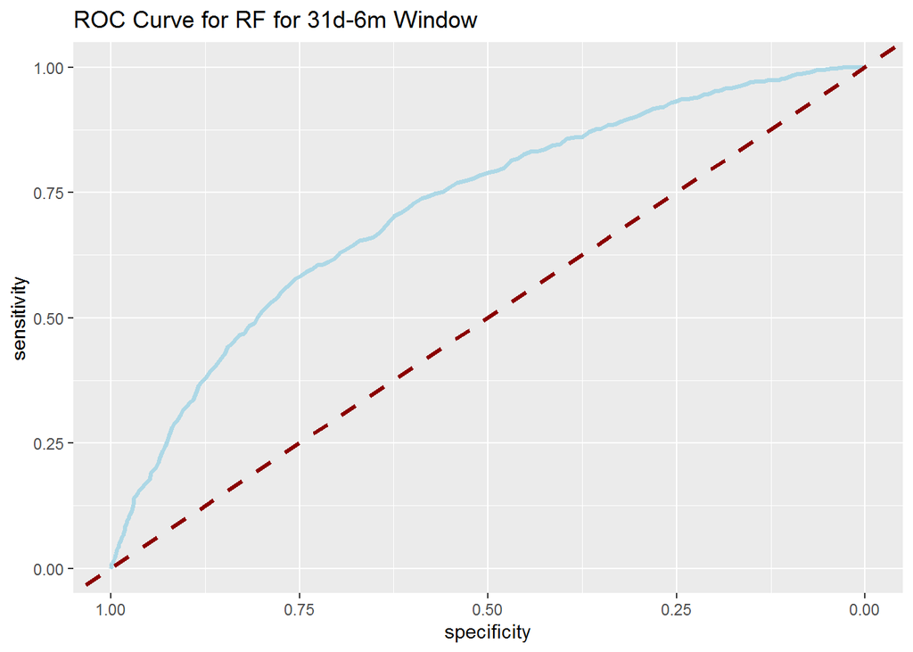

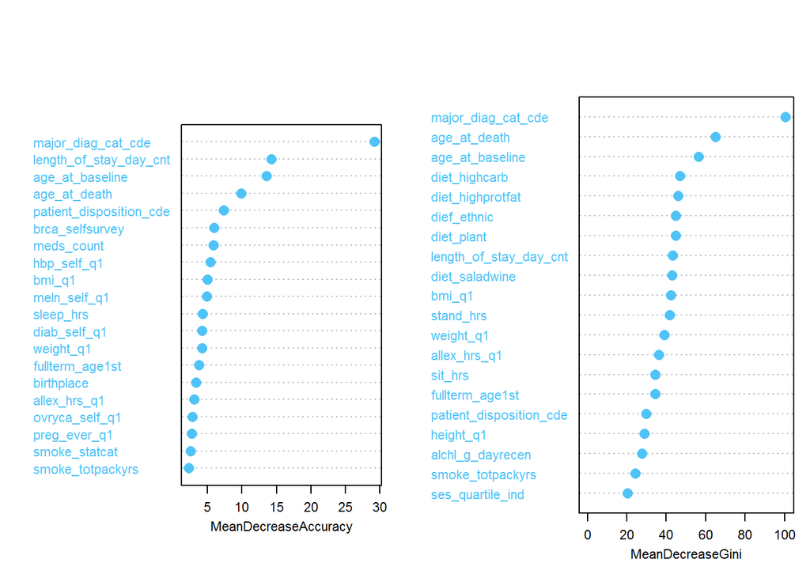

### Logistic Regression Model(s)

The main tool for binary classification learned throughout the PHDS program was logistic regression, and it is a formidable model type to try for this project. Building logistic regression models required more picky feature selection, as parsimonious models are often preferable and more interpretable. Especially with some factor variables nearing 24 levels, it was important to choose included features carefully to avoid overwhelmingly long output. Features were chosen with help of the variable importance plots from the random forest models, which helped initiate a preliminary model. Through forward selection and trial and error, AIC values of nested models would be compared. Ultimately, features were maintained if they were known to have significant clinical importance, were statistically significant in the output, or reduced AIC a sizable amount. For continuous variables, the fractional polynomial method was carried out to understand favorable transformations of those variables. Only one variable warranted a transformation, which was the count of procedures a participant had. The two logistic regression models actually had different independent variables included, as variables shifted in importance based on the window after discharge. For example, diagnoses were more important for the 0-30d model, while the model concerning death 31d-6mo benefited from inclusion of health behaviors like diet more. Balanced accuracy was calculated here as well.

```
##
## Call:
## glm(formula = death0to30 ~ patient_disposition_cde + bmi_q1 +
##     weight_q1 + I((proc_count + 0.01)^-2) + endoca_self_q1 +
##     colnca_self_q1 + diab_self_q1 + meln_self_q1 + length_of_stay_day_cnt +
##     hbp_self_q1 + ovryca_self_q1 + comorb_count + diet_highcarb +
##     age_at_baseline + smoke_totpackyrs + age_at_death, family = "binomial",
##     data = traindata_lr1)
##
## Deviance Residuals:
##     Min       1Q   Median       3Q      Max
## -3.5824  -0.1954  -0.1291  -0.1002   3.7122
##
## Coefficients: (2 not defined because of singularities)
##                                           Estimate Std. Error z value Pr(>|z|)
## (Intercept)                              -2.581219   1.109871  -2.326 0.020035
## patient_disposition_cde1                 -3.394105   0.361904  -9.378  < 2e-16
## patient_disposition_cde2                 -2.121773   0.378800  -5.601 2.13e-08
## patient_disposition_cde2.31022494464334 -61.983095 197.232580  -0.314 0.753321
## patient_disposition_cde3                 -2.244544   0.361529  -6.208 5.35e-10
## patient_disposition_cde4                 -2.205291   0.477488  -4.619 3.86e-06
## patient_disposition_cde6                 -2.329955   0.691671  -3.369 0.000756
## patient_disposition_cde7                  4.468606   0.441843  10.114  < 2e-16
## patient_disposition_cde8                 -2.321344   0.363944  -6.378 1.79e-10
## bmi_q1                                   -0.011956   0.022827  -0.524 0.600425
## weight_q1                                -0.001907   0.003614  -0.528 0.597619
## I((proc_count + 0.01)^-2)                       NA         NA      NA       NA
## endoca_self_q1B                           0.239402   0.337417   0.710 0.478006
## colnca_self_q1B                           1.142766   0.668924   1.708 0.087569
## diab_self_q1B                             0.273514   0.222545   1.229 0.219062
## meln_self_q1B                             0.320323   0.323483   0.990 0.322062
## length_of_stay_day_cnt                    0.043075   0.005886   7.318 2.52e-13
## hbp_self_q1B                             -0.112813   0.094850  -1.189 0.234291
## ovryca_self_q1B                          -0.231826   0.435258  -0.533 0.594299
## comorb_count                                    NA         NA      NA       NA
## diet_highcarb                             0.022680   0.052066   0.436 0.663130
## age_at_baseline                           0.174819   0.011860  14.740  < 2e-16
## smoke_totpackyrs                          0.005628   0.003105   1.813 0.069905
## age_at_death                             -0.140838   0.012296 -11.454  < 2e-16
##
```

[output cut: 19 more lines]

```
## comorb_count
## diet_highcarb
## age_at_baseline                         ***
## smoke_totpackyrs                        .
## age_at_death                            ***
## ---
## Signif. codes:  0 '***' 0.001 '**' 0.01 '*' 0.05 '.' 0.1 ' ' 1
##
## (Dispersion parameter for binomial family taken to be 1)
##
##     Null deviance: 9131.1  on 33826  degrees of freedom
## Residual deviance: 5368.8  on 33805  degrees of freedom
## AIC: 5412.8
##
## Number of Fisher Scoring iterations: 10
```

```
##     predicted
## true survive decease
##    0   14068      13
##    1     247     169
```

```
##                                            Overall
## patient_disposition_cde1                 9.3784762
## patient_disposition_cde2                 5.6013036
## patient_disposition_cde2.31022494464334  0.3142640
## patient_disposition_cde3                 6.2084829
## patient_disposition_cde4                 4.6185265
## patient_disposition_cde6                 3.3685889
## patient_disposition_cde7                10.1135710
## patient_disposition_cde8                 6.3782949
## bmi_q1                                   0.5237893
## weight_q1                                0.5278273
## endoca_self_q1B                          0.7095140
## colnca_self_q1B                          1.7083653
## diab_self_q1B                            1.2290271
## meln_self_q1B                            0.9902287
## length_of_stay_day_cnt                   7.3180899
## hbp_self_q1B                             1.1893767
## ovryca_self_q1B                          0.5326169
## diet_highcarb                            0.4355954
## age_at_baseline                         14.7398122
## smoke_totpackyrs                         1.8125254
## age_at_death                            11.4538627
```

```
##
## Call:
## glm(formula = death31to180 ~ brca_selfsurvey + patient_disposition_cde +
##     hbp_self_q1 + ovryca_self_q1 + smoke_totpackyrs + proc_count +
##     length_of_stay_day_cnt + colnca_self_q1 + meds_count + age_at_death +
##     age_at_baseline + diet_highcarb + comorb_count, family = "binomial",
##     data = traindata_lr2)
##
## Deviance Residuals:
##     Min       1Q   Median       3Q      Max
## -1.5724  -0.2888  -0.2388  -0.2014   3.2723
##
## Coefficients: (2 not defined because of singularities)
##                                           Estimate Std. Error z value Pr(>|z|)
## (Intercept)                             -2.490e+00  1.374e+00  -1.811   0.0701
## brca_selfsurveyN                         3.583e-01  1.046e+00   0.343   0.7319
## brca_selfsurveyY                         4.364e-01  1.050e+00   0.416   0.6777
## patient_disposition_cde1                 6.290e-01  7.588e-01   0.829   0.4071
## patient_disposition_cde2                 8.705e-01  7.665e-01   1.136   0.2561
## patient_disposition_cde2.31022494464334 -8.427e+01  3.956e+03  -0.021   0.9830
## patient_disposition_cde3                 1.055e+00  7.592e-01   1.389   0.1648
## patient_disposition_cde4                 1.511e+00  7.914e-01   1.909   0.0563
## patient_disposition_cde6                 1.090e+00  8.722e-01   1.249   0.2116
## patient_disposition_cde7                -1.474e+01  1.757e+02  -0.084   0.9331
## patient_disposition_cde8                 9.632e-01  7.601e-01   1.267   0.2051
## hbp_self_q1B                             1.016e-01  7.198e-02   1.412   0.1580
## ovryca_self_q1B                         -4.002e-01  2.788e-01  -1.435   0.1512
## smoke_totpackyrs                         5.414e-03  2.210e-03   2.449   0.0143
## proc_count                                      NA         NA      NA       NA
## length_of_stay_day_cnt                   4.105e-02  4.862e-03   8.444   <2e-16
## colnca_self_q1B                         -1.146e-01  2.766e-01  -0.414   0.6787
## meds_count                              -4.671e-02  3.279e-02  -1.424   0.1544
## age_at_death                            -1.951e-01  9.286e-03 -21.013   <2e-16
## age_at_baseline                          2.152e-01  8.958e-03  24.021   <2e-16
## diet_highcarb                           -5.319e-02  3.489e-02  -1.524   0.1274
## comorb_count                                    NA         NA      NA       NA
##
## (Intercept)                             .
## brca_selfsurveyN
## brca_selfsurveyY
```

[output cut: 14 more lines]

```
## meds_count
## age_at_death                            ***
## age_at_baseline                         ***
## diet_highcarb
## comorb_count
## ---
## Signif. codes:  0 '***' 0.001 '**' 0.01 '*' 0.05 '.' 0.1 ' ' 1
##
## (Dispersion parameter for binomial family taken to be 1)
##
##     Null deviance: 11608  on 33826  degrees of freedom
## Residual deviance: 10605  on 33807  degrees of freedom
## AIC: 10645
##
## Number of Fisher Scoring iterations: 16
```

```
##     predicted
## true survive decease
##    0   13872       4
##    1     616       5
```

```
##                                             Overall
## brca_selfsurveyN                         0.34262929
## brca_selfsurveyY                         0.41565450
## patient_disposition_cde1                 0.82896378
## patient_disposition_cde2                 1.13576362
## patient_disposition_cde2.31022494464334  0.02130001
## patient_disposition_cde3                 1.38905031
## patient_disposition_cde4                 1.90885807
## patient_disposition_cde6                 1.24918563
## patient_disposition_cde7                 0.08390825
## patient_disposition_cde8                 1.26715188
## hbp_self_q1B                             1.41169710
## ovryca_self_q1B                          1.43518669
## smoke_totpackyrs                         2.44914500
## length_of_stay_day_cnt                   8.44389961
## colnca_self_q1B                          0.41422562
## meds_count                               1.42428232
## age_at_death                            21.01268603
## age_at_baseline                         24.02064978
## diet_highcarb                            1.52440064
```

### Gradient Boosting

```
##                Length Class              Mode
## handle              1 xgb.Booster.handle externalptr
## raw            114286 -none-             raw
## niter               1 -none-             numeric
## evaluation_log      2 data.table         list
## call               15 -none-             call
## params              3 -none-             list
## callbacks           1 -none-             list
## feature_names      51 -none-             character
## nfeatures           1 -none-             numeric
```

```
## Confusion Matrix and Statistics
##
##           Reference
## Prediction     0     1
##          0 14070    11
##          1   286   130
##
##                Accuracy : 0.9795
##                  95% CI : (0.9771, 0.9818)
##     No Information Rate : 0.9903
##     P-Value [Acc > NIR] : 1
##
##                   Kappa : 0.4589
##
##  Mcnemar's Test P-Value : <2e-16
##
##             Sensitivity : 0.9801
##             Specificity : 0.9220
##          Pos Pred Value : 0.9992
##          Neg Pred Value : 0.3125
##              Prevalence : 0.9903
##          Detection Rate : 0.9705
##    Detection Prevalence : 0.9713
##       Balanced Accuracy : 0.9510
##
##        'Positive' Class : 0
##
```

```
##                     Feature         Gain        Cover   Frequency
##  1: patient_disposition_cde 5.429232e-01 1.213801e-01 0.099337748
##  2:             dief_ethnic 7.441483e-02 5.755171e-02 0.052980132
##  3:          diag_ccs_code1 5.514895e-02 9.655292e-02 0.074503311
##  4:          diet_saladwine 5.105271e-02 5.590816e-02 0.046357616
##  5:       facility_zip5_cde 3.718010e-02 1.404005e-02 0.014900662
##  6:        smoke_totpackyrs 3.699656e-02 2.401947e-02 0.033112583
##  7:        diet_highprotfat 3.044915e-02 2.629792e-02 0.038079470
##  8:               weight_q1 2.904344e-02 2.917586e-02 0.071192053
##  9:          diag_ccs_code3 2.515218e-02 3.868980e-02 0.031456954
## 10:      major_diag_cat_cde 1.901058e-02 5.673111e-02 0.041390728
## 11:         age_at_baseline 1.799975e-02 6.125354e-02 0.056291391
## 12:          diag_ccs_code4 1.334449e-02 2.074734e-02 0.026490066
## 13:  length_of_stay_day_cnt 7.737400e-03 1.493055e-01 0.109271523
## 14:              diet_plant 7.357428e-03 6.831096e-03 0.008278146
```

[output cut: 26 more lines]

```
##                Length Class              Mode
## handle              1 xgb.Booster.handle externalptr
## raw            110662 -none-             raw
## niter               1 -none-             numeric
## evaluation_log      2 data.table         list
## call               15 -none-             call
## params              3 -none-             list
## callbacks           1 -none-             list
## feature_names      51 -none-             character
## nfeatures           1 -none-             numeric
```

```
##
##     0     1
## 13876   621
```

```
## Confusion Matrix and Statistics
##
##           Reference
## Prediction     0     1
##          0 13873     3
##          1   621     0
##
##                Accuracy : 0.957
##                  95% CI : (0.9535, 0.9602)
##     No Information Rate : 0.9998
##     P-Value [Acc > NIR] : 1
##
##                   Kappa : -4e-04
##
##  Mcnemar's Test P-Value : <2e-16
##
##             Sensitivity : 0.9572
##             Specificity : 0.0000
##          Pos Pred Value : 0.9998
##          Neg Pred Value : 0.0000
##              Prevalence : 0.9998
##          Detection Rate : 0.9570
##    Detection Prevalence : 0.9572
##       Balanced Accuracy : 0.4786
##
##        'Positive' Class : 0
##
```

```
##                     Feature         Gain        Cover   Frequency
##  1:           diet_highcarb 1.161536e-01 7.025958e-02 0.078671329
##  2:        smoke_totpackyrs 9.380957e-02 4.566095e-02 0.059440559
##  3:              diet_plant 8.603221e-02 4.561545e-02 0.050699301
##  4:          diet_saladwine 7.553330e-02 8.509672e-02 0.061188811
##  5:  length_of_stay_day_cnt 6.914447e-02 6.973391e-02 0.064685315
##  6:                  bmi_q1 6.293222e-02 3.997573e-02 0.050699301
##  7:             dief_ethnic 5.523441e-02 2.620058e-02 0.024475524
##  8:         age_at_baseline 4.924194e-02 4.305625e-02 0.052447552
##  9:       facility_zip5_cde 4.621542e-02 2.677806e-03 0.026223776
## 10:        diet_highprotfat 4.112447e-02 4.994885e-02 0.041958042
## 11:        alchl_g_dayrecen 3.974181e-02 1.713396e-02 0.020979021
## 12:               height_q1 3.619050e-02 1.032884e-02 0.020979021
## 13:        ses_quartile_ind 3.151546e-02 1.009504e-02 0.020979021
## 14:               weight_q1 3.009385e-02 2.215512e-02 0.033216783
```

[output cut: 28 more lines]

Outputs from both XGBoost models interestingly demonstrate differences in predictive ability between the two categories of discharge to death elapsed time. The balanced accuracy of the model for the first 30 days after discharge is far more than that of the model looking at 30 days until 6 months (~95% vs. ~50%). The second model seems to poorly classify deceased participants, while the first does well with classification for both with its great specificity and sensitivity.

## Aim #1 Conclusion: Best Models to Predict Death

### Comparing Model Benefits

The three models utilized in this report are vastly different from one another and offer different benefits as a result. Logistic regression offers more quantitative reporting, with odds ratios derivable from coefficients holding other independent variables constant. On the other hand, the XGBoost model, though not quantitatively interpretable, offers greater predictive performance.

### Comparing Model Test Statistics

For this particular report, the statistic used was balanced accuracy, as the AUC was not able to represent such an imbalanced dataset for the target variable. For the three models utilized (RF, LR, XGB), the balanced accuracies were as follows:

- Random forest:
  - Model #1 (first 30 days after discharge): 58.13%
  - Model #2 (31 days to 6 months after discharge): 53.71%
- Logistic regression:
  - Model #1 (first 30 days after discharge): 70.27%
  - Model #2 (31 days to 6 months after discharge): 50.39%
- XGBoost:
  - Model #1 (first 30 days after discharge): 95.10%
  - Model #2 (31 days to 6 months after discharge): 47.86%

Based on the above statistics, the best model for predicting death among participants for the two discharge to death categories were:

- First 30 days: XGBoost (95.10%)
- 31 days to 6 months: Random Forest (53.71%)

## Aim #2 Conclusion: Time Window Matters for Predicting

As seen throughout this report and from the conclusion for Aim #1, time window clearly makes a difference when predicting death. Between the two windows investigated (0-30d and 31d-6m), there were clear predictive performance differences that demonstrate that time windows after discharge affect models. As indicated in toward the beginning of this report, it logically makes more sense to have more accurate models closer to hospital discharge because variables are more accurate without as much elapsed time. Furthermore, the more time that passes post-discharge, the more room for other life events, health changes, and other participant variables to change. That way, death may become less associated with hospitalization and other recorded variables as time goes on. Also, seeing that variable importance shifts as different time windows are used with the same models, time windows are also different for the variables that are most associated with death.

## Aim #3 Conclusion: Co-morbidities Matter

Certain co-morbidities impact the risk of death more or less than others. The most obvious diagnoses that impact risk of death were cancer-related diagnoses, as different cancer variables were repeatedly in important variable plots/lists for different models. For example, endometrial cancer being deemed more important than ovarian cancer for a model reveals that those with the former cancer may be better predicted than the latter. Looking at this aim more quantitatively, the logistic regression models demonstrate odds ratios of features as well. Based o the magnitude and sign of coefficients in the logistic regression models, there are clear differences in how some conditions affect risk of death. Exemplary of this is having colon cancer (1.14 coefficients), holding other variables constant, increases risk of death in the first 30 days after discharge more than having diabetes (0.273). Of course, having both conditions would more significantly impact one’s susceptibility to death.

## Aim #4 Conclusion: Spatial and Temporal Associations Lacking

Looking at plots produced earlier in the report during univariate and bivariate analyses, there were no evident differences in seasonality/temporality for death. The produced bar chart shows little to no differences in death counts for winter, fall, spring, and summer. Also, spatial associations are difficult to entirely comprehend without supplemental data like population size or deaths per county. A summary table was created earlier in the report to look at decease counts for each county, specifically looking at the 5 counties where death is most common. Naturally, death most often occurred in counties with more facilities/hospitals. The population density dilemma for figuring out spatial associations could be solved with data supplied from governmental sources or other trustworthy repositories. If any hypotheses were to be made for spatial associations, it may make most sense for deaths to disproportionately affect rural areas that have less resources and well-off health facilities.

## Proposals

Upon investigating the four aims and getting to work with the data hands-on, I have some proposals I think are worth sharing.

1. Including population-level data for each county, like deaths per county or number of women per county, would be interesting to do analyses like the spatial associations. This could help to standardize death rates and make them comparable across counties.
2. Based on the variables indicated as important across the many models made, prioritize enforcing data managers or people who record data to ensure important variables are not missing. It could be helpful when predicting their risk of death to have complete data for variables that matter most!
3. Focus on the important and impactful behavioral variables in models, for they are the ones that have potential to change rather than chronic diagnoses. If high carbohydrate diets are more impactful on people during their 31d to 6mo after discharge, implementing a program to inform people on nutrition importance would be beneficial.

## Reflection

Overall, this project was academically stimulating and so enjoyable! Throughout the core courses of the PHDS, a lot of data used was either publically available, fabricated, or from potentially dated health sources. To gain access to valuable data from the CTS and have the privilege to create meaningful tools to predict death for future participants was neat! In the real world, experiencing this level of security with sensitive data was important to mimic what will eventually happen after graduation in the workforce. Receiving a statistical plan with generic explanation of expectations was also valuable, since we were not “hand-held” through the process and were essentially forced to make our own unique approaches to the project. Again, that mimicked the real world and the job of a professional data scientist, in which plans are provided and results are expected from the data scientist in an efficient manner. I will miss this program a whole lot, and I am incredibly grateful for what it has given me! Finishing this project was incredibly fulfilling and is something I feel really accomplished about.